# Asymptomatic malaria parasitaemia in household members of confirmed malaria patients

Dataset 13: Asymptomatic malaria in households of confirmed cases in Abuja

RSR feasibility analysis

2026-08-03

# Introduction

Onyiah and colleagues carried out a cross-sectional household survey in the Federal Capital Territory, Abuja, Nigeria between March and August 2016 (*PLOS ONE* 2018, doi:10.1371/journal.pone.0203686). Laboratory-confirmed malaria patients were recruited consecutively from twelve health facilities in three randomly selected area councils; their households were then visited within seven days and all consenting members were enrolled and screened, giving 602 participants from 107 households. Asymptomatic parasitaemia matters because people carrying parasites without symptoms are not treated, and so act as a silent reservoir that sustains transmission around a treated index case.

**Aim.** Among household members of confirmed malaria patients in Abuja, we examined which of age, sex, education, area council, bushes around the home, insecticidal net use, housing quality, sleeping in the same room as the index case and uncovered water receptacles are independently associated with asymptomatic malaria parasitaemia, mutually adjusting for the others.

This is a *Purpose 3* analysis: several predictors are of interest and the question is which remain associated with the outcome after mutual adjustment.

# Methods

**Data source.** A cross-sectional household survey in three of the six Abuja area councils (Abuja Municipal, Kuje, Kwali), March to August 2016. Index cases were patients with microscopy- or RDT-confirmed malaria attending twelve selected health facilities; the sampling unit for this analysis is the household member, and this teaching extract holds 602 household members with 15 variables. Because entry into the sample required living with a confirmed malaria patient, **the sample is selected on exposure to a household infection** and nothing here is a population prevalence estimate.

**Variables.** The outcome is `malaria_parasitaemia`, a binary indicator where the **event is a positive thick-film microscopy result**. There are 421 events and 181 non-events in the file, i.e. 69.9% positive. This is worth pausing on: the event is the *majority* class, which is unusual for a disease outcome and has a practical consequence noted under the parameter budget below. Predictors are age group (reference 20 and over), sex (reference female), highest education (reference none), area council (reference Abuja Municipal, the largest), bushes around the home (reference no), insecticidal net status (reference no net), a housing-quality index (reference improved, the largest group), sleeping in the same room as the index case (reference no) and uncovered water receptacles near the home (reference no).

**Three predictors were reshaped before any model was fitted.** *(i)* The five housing variables `house_floor`, `house_roof`, `house_type`, `house_wall` and `house_window` are five correlated measurements of one underlying construct, housing quality; pairwise correlations between the “improved” indicators derived from them run from 0.38 to 0.78, and the cross-tabulations contain structural zeros (every one of the 77 huts has mud walls and none has screened or glass windows; all 341 ceramic-tiled dwellings have screened or glass windows). Entered together they cost 11 parameters and generate a variance inflation factor of about 27 for `house_window`. They were therefore replaced by a single index counting how many of five “improved” features a dwelling has (ceramic-tiled floor, cement-plastered walls, metal or shingle roof, screened or glass windows, a dwelling other than a hut), collapsed to three levels. *(ii)* `owns_llin` and `used_llin_previous_night` are **exactly nested**: all 107 participants who used a net owned one, and all 454 non-owners are coded 0 for use, so the “did not use” category silently mixes people with no net and people with an unused net. They were combined into one three-level variable. *(iii)* `age_group` was collapsed from six levels to four, because the 20-24 stratum holds only 50 participants and the three adult strata have nearly identical parasitaemia (70.0%, 68.5% and 61.8%); the childhood strata, which are the clinically interesting ones, are kept separate.

**Parameter budget.** The fourteen predictors as shipped cost 27 parameters. The relevant denominator for the ten-events-per- parameter rule is not the 421 positives but the 181 **negatives**, because a logistic model is constrained by the smaller of the two outcome classes; the shipped set therefore runs at 6.7 per parameter, below the conventional minimum. The reduced set above costs 16 parameters, i.e. 11.3 negatives per parameter, which clears it. The budget was fixed before any model was fitted.

**Statistical analysis.** `glm(family = binomial)`, justified because the outcome is binary. We fitted a univariable model for each predictor first, then a single multivariable model containing all of them. Predictors were chosen in advance on subject-matter grounds, not by significance. Coefficients are exponentiated and reported as odds ratios with 95% confidence intervals; significance threshold 0.05. Model adequacy was assessed with `performance::check_model()`, focusing on binned residuals, collinearity, influential observations and events per parameter, and every categorical predictor was cross-tabulated against the outcome to check for separation before fitting. **The models treat the 602 participants as independent, which they are not**: they sit inside 107 households, and no household identifier is shipped in this extract, so the clustering cannot be adjusted for here. The consequences are set out under Limitations. Analysis used R version 4.6.0 (2026-04-24) with tidyverse, gtsummary and performance.

**Missing data.** There is none. All 15 columns are 100% complete, so the complete-case analysis retains 602 of 602 rows (0 dropped) and all 421 events. This is the one respect in which the dataset is unusually easy to work with.

# Results

## Sample characteristics

**Table 1. Sample characteristics by microscopy result.**

| **Characteristic** | **N** | **Negative** N = 181<sup>1</sup> | **Positive** N = 421<sup>1</sup> |
| --- | --- | --- | --- |
| Age group (years) | 602 |  |  |
| 20 and over |  | 89 (49%) | 174 (41%) |
| 10-19 |  | 46 (25%) | 90 (21%) |
| 5-9 |  | 22 (12%) | 90 (21%) |
| Under 5 |  | 24 (13%) | 67 (16%) |
| Sex | 602 |  |  |
| Female |  | 111 (61%) | 220 (52%) |
| Male |  | 70 (39%) | 201 (48%) |
| Highest education level | 602 |  |  |
| None |  | 24 (13%) | 103 (24%) |
| Primary |  | 47 (26%) | 117 (28%) |
| Secondary |  | 63 (35%) | 119 (28%) |
| Tertiary |  | 47 (26%) | 82 (19%) |
| Area council | 602 |  |  |
| Abuja Municipal |  | 110 (61%) | 275 (65%) |
| Kuje |  | 56 (31%) | 120 (29%) |
| Kwali |  | 15 (8.3%) | 26 (6.2%) |
| Bushes around the home | 602 | 41 (23%) | 169 (40%) |
| Insecticidal net | 602 |  |  |
| No net |  | 134 (74%) | 320 (76%) |
| Owns, not used last night |  | 12 (6.6%) | 29 (6.9%) |
| Owns, used last night |  | 35 (19%) | 72 (17%) |
| Housing quality index | 602 |  |  |
| Improved (all 5) |  | 89 (49%) | 236 (56%) |
| Intermediate (3-4) |  | 60 (33%) | 102 (24%) |
| Basic (0-2 features) |  | 32 (18%) | 83 (20%) |
| Sleeps in same room as index case | 602 | 93 (51%) | 190 (45%) |
| Uncovered water receptacles | 602 | 24 (13%) | 52 (12%) |

<sup>1</sup> n (%)

Positives outnumber negatives in every stratum of every predictor, which is the direct consequence of a 69.9% overall positivity rate; the informative comparisons are therefore between columns rather than within them. The clearest contrast is bushes around the home, present for 40.1% of positives against 22.7% of negatives, and education, where 24.5% of positives have no formal education against 13.3% of negatives. Net status and sleeping in the same room as the index case look almost identical in the two columns.

## Exploratory figure

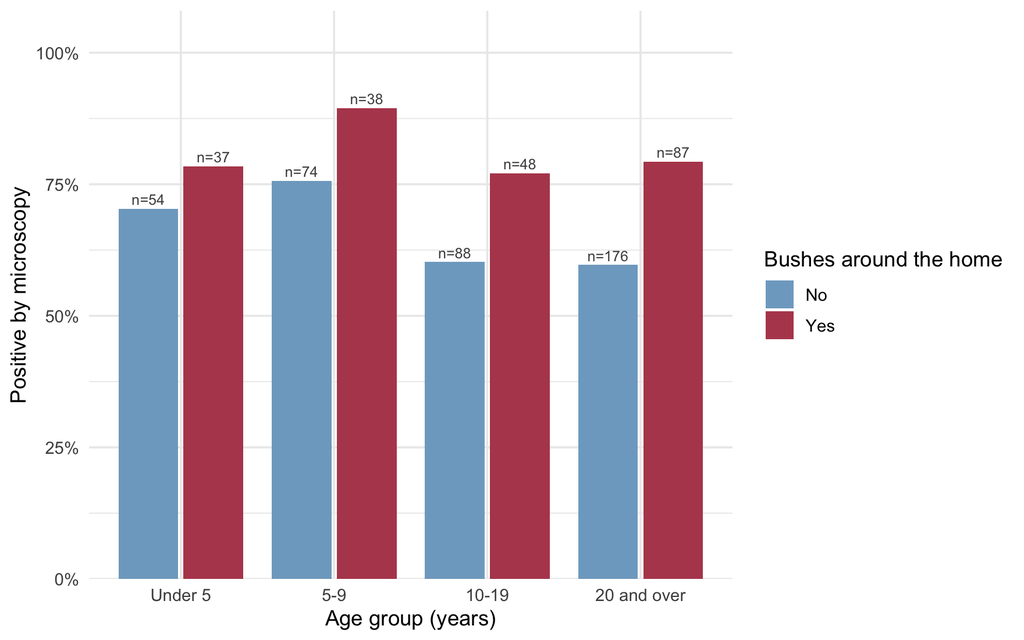

Figure 1. Percentage of household members with microscopy-positive malaria parasitaemia, by age group and whether there are bushes around the home.

Parasitaemia is higher where there are bushes around the home in every age group, and the age pattern is a childhood peak at 5-9 years rather than a gradient: the school-age children in bushy compounds are the highest-prevalence cell in the figure at 89.5%.

## Univariable models

| **Characteristic** | **N** | **OR** | **95% CI** | **p-value** |
| --- | --- | --- | --- | --- |
| Age group (years) | 602 |  |  |  |
| 20 and over |  | — | — |  |
| 10-19 |  | 1.00 | 0.65, 1.56 | >0.9 |
| 5-9 |  | 2.09 | 1.25, 3.63 | 0.006 |
| Under 5 |  | 1.43 | 0.85, 2.47 | 0.2 |
| Sex | 602 |  |  |  |
| Female |  | — | — |  |
| Male |  | 1.45 | 1.02, 2.07 | 0.041 |
| Highest education level | 602 |  |  |  |
| None |  | — | — |  |
| Primary |  | 0.58 | 0.33, 1.01 | 0.056 |
| Secondary |  | 0.44 | 0.25, 0.75 | 0.003 |
| Tertiary |  | 0.41 | 0.23, 0.71 | 0.002 |
| Area council | 602 |  |  |  |
| Abuja Municipal |  | — | — |  |
| Kuje |  | 0.86 | 0.58, 1.27 | 0.4 |
| Kwali |  | 0.69 | 0.36, 1.39 | 0.3 |
| Bushes around the home | 602 |  |  |  |
| No |  | — | — |  |
| Yes |  | 2.29 | 1.55, 3.44 | <0.001 |
| Insecticidal net | 602 |  |  |  |
| No net |  | — | — |  |
| Owns, not used last night |  | 1.01 | 0.51, 2.12 | >0.9 |
| Owns, used last night |  | 0.86 | 0.55, 1.36 | 0.5 |
| Housing quality index | 602 |  |  |  |
| Improved (all 5) |  | — | — |  |
| Intermediate (3-4) |  | 0.64 | 0.43, 0.96 | 0.030 |
| Basic (0-2 features) |  | 0.98 | 0.61, 1.59 | >0.9 |
| Sleeps in same room as index case | 602 |  |  |  |
| No |  | — | — |  |
| Yes |  | 0.78 | 0.55, 1.10 | 0.2 |
| Uncovered water receptacles | 602 |  |  |  |
| No |  | — | — |  |
| Yes |  | 0.92 | 0.55, 1.57 | 0.8 |

Abbreviations: CI = Confidence Interval, OR = Odds Ratio

Bushes around the home carry the strongest crude association: their presence multiplies the odds of parasitaemia by OR 2.29 (95% CI 1.55 to 3.44) (p <0.001). Education shows a monotone crude gradient against the no-education reference — primary OR 0.58 (95% CI 0.33 to 1.01) (p = 0.056), secondary OR 0.44 (95% CI 0.25 to 0.75) (p = 0.003) and tertiary OR 0.41 (95% CI 0.23 to 0.71) (p = 0.002) — and age shows a peak rather than a gradient, with children aged 5-9 at OR 2.09 (95% CI 1.25 to 3.63) (p = 0.006) relative to adults while under-5s (OR 1.43 (95% CI 0.85 to 2.47), p = 0.189) and 10-19 year-olds (OR 1.00 (95% CI 0.65 to 1.56), p = 0.997) are not distinguishable from them. Men have OR 1.45 (95% CI 1.02 to 2.07) (p = 0.041), just inside the threshold. Intermediate housing sits at OR 0.64 (95% CI 0.43 to 0.96) (p = 0.030) but basic housing does not (OR 0.98 (95% CI 0.61 to 1.59), p = 0.927), so the housing “gradient” is not monotone and should not be read as one.

Three predictors that the study design puts front and centre are flatly null in crude analysis. Sleeping in the same room as the index case gives OR 0.78 (95% CI 0.55 to 1.10) (p = 0.159) — the point estimate is if anything *protective*. Owning and using a net the previous night gives OR 0.86 (95% CI 0.55 to 1.36) (p = 0.517), and owning a net but not using it gives OR 1.01 (95% CI 0.51 to 2.12) (p = 0.973), so neither ownership nor use marks lower parasitaemia. Uncovered water receptacles give OR 0.92 (95% CI 0.55 to 1.57) (p = 0.758), and neither of the two non-reference area councils differs from Abuja Municipal (Kuje OR 0.86 (95% CI 0.58 to 1.27), p = 0.435; Kwali OR 0.69 (95% CI 0.36 to 1.39), p = 0.286).

## Why adjustment is needed

**Area council** confounds the housing and bushes associations. The three councils differ sharply in dwelling stock: only 3.1% of Abuja Municipal participants live in basic housing against 50.6% in Kuje, and bushes around the home are reported by 29.6% of Abuja Municipal households against 47.7% in Kuje. Area council is also plausibly related to the outcome independently of either, because the councils differ in transmission intensity, vector density and distance to care. Without adjustment, a housing coefficient is partly a geography coefficient.

**Age** confounds the education association, and severely. Education in a household survey is largely an age marker for children: of the 203 participants under ten, 198 are recorded as having no education or primary education only and the remaining 5 as secondary; not one is recorded as tertiary, whereas 48.3% of the adults are. The low-education strata are therefore dominated by exactly the young children who have the highest parasitaemia for immunological reasons. Age is independently related to the outcome through acquired immunity, and it is related to recorded education by construction. The crude education gradient therefore cannot be read as an effect of schooling or of the socioeconomic position it proxies until age is held constant.

## Multivariable model

| **Characteristic** | **OR** | **95% CI** | **p-value** |
| --- | --- | --- | --- |
| Age group (years) |  |  |  |
| 20 and over | — | — |  |
| 10-19 | 1.04 | 0.61, 1.78 | 0.9 |
| 5-9 | 2.18 | 1.04, 4.66 | 0.042 |
| Under 5 | 1.01 | 0.47, 2.15 | >0.9 |
| Sex |  |  |  |
| Female | — | — |  |
| Male | 1.43 | 0.99, 2.10 | 0.060 |
| Highest education level |  |  |  |
| None | — | — |  |
| Primary | 0.47 | 0.24, 0.92 | 0.030 |
| Secondary | 0.53 | 0.26, 1.07 | 0.081 |
| Tertiary | 0.43 | 0.19, 0.93 | 0.035 |
| Area council |  |  |  |
| Abuja Municipal | — | — |  |
| Kuje | 0.62 | 0.38, 1.03 | 0.066 |
| Kwali | 0.58 | 0.23, 1.41 | 0.2 |
| Bushes around the home |  |  |  |
| No | — | — |  |
| Yes | 2.25 | 1.46, 3.54 | <0.001 |
| Insecticidal net |  |  |  |
| No net | — | — |  |
| Owns, not used last night | 1.29 | 0.55, 3.24 | 0.6 |
| Owns, used last night | 1.00 | 0.62, 1.64 | >0.9 |
| Housing quality index |  |  |  |
| Improved (all 5) | — | — |  |
| Intermediate (3-4) | 0.70 | 0.45, 1.08 | 0.11 |
| Basic (0-2 features) | 0.92 | 0.48, 1.75 | 0.8 |
| Sleeps in same room as index case |  |  |  |
| No | — | — |  |
| Yes | 0.81 | 0.55, 1.18 | 0.3 |
| Uncovered water receptacles |  |  |  |
| No | — | — |  |
| Yes | 0.69 | 0.39, 1.25 | 0.2 |

Abbreviations: CI = Confidence Interval, OR = Odds Ratio

**Model fit: multivariable logistic model for malaria parasitaemia**

| Statistic | Value |
| --- | --- |
| Complete-case N | 602 |
| Events (parasitaemia = 1) | 421 |
| Non-events (parasitaemia = 0) | 181 |
| Parameters (excl. intercept) | 16 |
| Events per parameter | 26.3 |
| Non-events per parameter (binding) | 11.3 |
| AIC (null model) | 738.2 |
| AIC (full model) | 722.6 |
| Tjur's R-squared | 0.076 |

The model carries 16 parameters. On the usual count that is 26.3 events per parameter, comfortably clear of ten, but that number flatters the model: because the event is the majority class the binding constraint is the 181 negatives, giving 11.3 per parameter. AIC falls only from 738.2 for the intercept-only model to 722.6, a drop of 15.5, and Tjur’s R-squared is 0.076. The nine predictors together explain very little: with 69.9% of everybody positive, the model has limited room to discriminate.

Among participants of the same sex, education, area council, housing, net status, room-sharing and water storage, bushes around the home remain associated with OR 2.25 (95% CI 1.46 to 3.54) (p <0.001) — essentially unchanged from the crude estimate and the only predictor significant at 0.05 with a wide margin. Among participants alike on everything else, children aged 5-9 have OR 2.18 (95% CI 1.04 to 4.66) (p = 0.042) relative to adults, while under-5s (OR 1.01 (95% CI 0.47 to 2.15)) and 10-19 year-olds (OR 1.04 (95% CI 0.61 to 1.78)) are indistinguishable from adults. Education retains a gradient after adjustment: tertiary OR 0.43 (95% CI 0.19 to 0.93) (p = 0.035) and primary OR 0.47 (95% CI 0.24 to 0.92) (p = 0.030) against no education, though secondary (OR 0.53 (95% CI 0.26 to 1.07), p = 0.081) is not significant and the levels are not ordered as a clean dose-response.

The three design-relevant exposures stay null. Sleeping in the same room as the index case gives OR 0.81 (95% CI 0.55 to 1.18) (p = 0.266); using a net the previous night gives OR 1.00 (95% CI 0.62 to 1.64) (p = 0.993), and owning an unused net OR 1.29 (95% CI 0.55 to 3.24) (p = 0.569). Housing quality (OR 0.70 (95% CI 0.45 to 1.08) for intermediate, OR 0.92 (95% CI 0.48 to 1.75) for basic) and uncovered water receptacles (OR 0.69 (95% CI 0.39 to 1.25)) are also null. These are associations among the participants observed, not effects of intervening.

## Unadjusted versus adjusted

**Table 2. Unadjusted and adjusted odds ratios.**

| **Characteristic** | **Unadjusted** **N** | **Unadjusted** **OR** | **Unadjusted** **95% CI** | **Unadjusted** **p-value** | **Adjusted** **OR** | **Adjusted** **95% CI** | **Adjusted** **p-value** |
| --- | --- | --- | --- | --- | --- | --- | --- |
| Age group (years) | 602 |  |  |  |  |  |  |
| 20 and over |  | — | — |  | — | — |  |
| 10-19 |  | 1.00 | 0.65, 1.56 | >0.9 | 1.04 | 0.61, 1.78 | 0.9 |
| 5-9 |  | 2.09 | 1.25, 3.63 | 0.006 | 2.18 | 1.04, 4.66 | 0.042 |
| Under 5 |  | 1.43 | 0.85, 2.47 | 0.2 | 1.01 | 0.47, 2.15 | >0.9 |
| Sex | 602 |  |  |  |  |  |  |
| Female |  | — | — |  | — | — |  |
| Male |  | 1.45 | 1.02, 2.07 | 0.041 | 1.43 | 0.99, 2.10 | 0.060 |
| Highest education level | 602 |  |  |  |  |  |  |
| None |  | — | — |  | — | — |  |
| Primary |  | 0.58 | 0.33, 1.01 | 0.056 | 0.47 | 0.24, 0.92 | 0.030 |
| Secondary |  | 0.44 | 0.25, 0.75 | 0.003 | 0.53 | 0.26, 1.07 | 0.081 |
| Tertiary |  | 0.41 | 0.23, 0.71 | 0.002 | 0.43 | 0.19, 0.93 | 0.035 |
| Area council | 602 |  |  |  |  |  |  |
| Abuja Municipal |  | — | — |  | — | — |  |
| Kuje |  | 0.86 | 0.58, 1.27 | 0.4 | 0.62 | 0.38, 1.03 | 0.066 |
| Kwali |  | 0.69 | 0.36, 1.39 | 0.3 | 0.58 | 0.23, 1.41 | 0.2 |
| Bushes around the home | 602 |  |  |  |  |  |  |
| No |  | — | — |  | — | — |  |
| Yes |  | 2.29 | 1.55, 3.44 | <0.001 | 2.25 | 1.46, 3.54 | <0.001 |
| Insecticidal net | 602 |  |  |  |  |  |  |
| No net |  | — | — |  | — | — |  |
| Owns, not used last night |  | 1.01 | 0.51, 2.12 | >0.9 | 1.29 | 0.55, 3.24 | 0.6 |
| Owns, used last night |  | 0.86 | 0.55, 1.36 | 0.5 | 1.00 | 0.62, 1.64 | >0.9 |
| Housing quality index | 602 |  |  |  |  |  |  |
| Improved (all 5) |  | — | — |  | — | — |  |
| Intermediate (3-4) |  | 0.64 | 0.43, 0.96 | 0.030 | 0.70 | 0.45, 1.08 | 0.11 |
| Basic (0-2 features) |  | 0.98 | 0.61, 1.59 | >0.9 | 0.92 | 0.48, 1.75 | 0.8 |
| Sleeps in same room as index case | 602 |  |  |  |  |  |  |
| No |  | — | — |  | — | — |  |
| Yes |  | 0.78 | 0.55, 1.10 | 0.2 | 0.81 | 0.55, 1.18 | 0.3 |
| Uncovered water receptacles | 602 |  |  |  |  |  |  |
| No |  | — | — |  | — | — |  |
| Yes |  | 0.92 | 0.55, 1.57 | 0.8 | 0.69 | 0.39, 1.25 | 0.2 |

Abbreviations: CI = Confidence Interval, OR = Odds Ratio

Two coefficients barely move. **Bushes** goes from OR 2.29 (95% CI 1.55 to 3.44) to OR 2.25 (95% CI 1.46 to 3.54), a shift of a few percent, so its association is essentially independent of everything else measured; and **tertiary education** goes from OR 0.41 (95% CI 0.23 to 0.71) to OR 0.43 (95% CI 0.19 to 0.93).

## Diagnostics

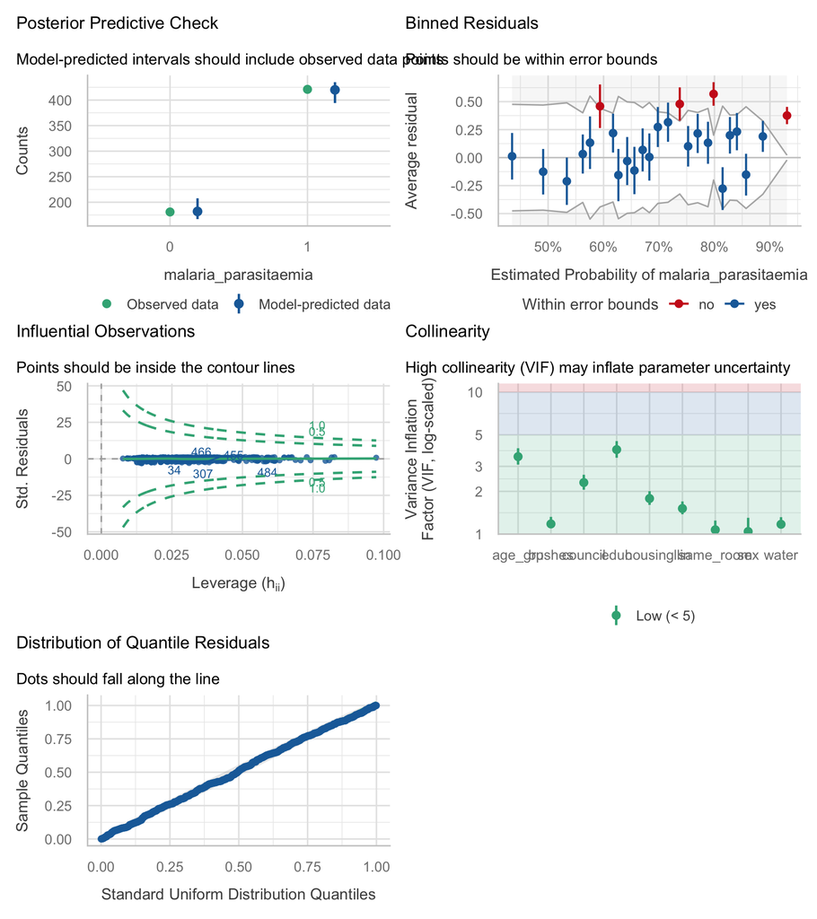

| Term | VIF | VIF_CI_low | VIF_CI_high | SE_factor | Tolerance | Tolerance_CI_low | Tolerance_CI_high |
| --- | --- | --- | --- | --- | --- | --- | --- |
| age_grp | 3.513988 | 3.088652 | 4.025939 | 1.233010 | 0.2845770 | 0.2483892 | 0.3237658 |
| sex | 1.043015 | 1.006110 | 1.302847 | 1.021281 | 0.9587588 | 0.7675497 | 0.9939274 |
| educ | 3.936869 | 3.450814 | 4.519320 | 1.256585 | 0.2540090 | 0.2212722 | 0.2897867 |
| council | 2.307514 | 2.055911 | 2.619069 | 1.232498 | 0.4333668 | 0.3818150 | 0.4864023 |
| bushes | 1.179922 | 1.100312 | 1.322714 | 1.086242 | 0.8475134 | 0.7560215 | 0.9088332 |
| llin | 1.515223 | 1.379921 | 1.698711 | 1.109479 | 0.6599689 | 0.5886816 | 0.7246794 |
| housing | 1.781313 | 1.606336 | 2.006784 | 1.155274 | 0.5613837 | 0.4983098 | 0.6225346 |
| same_room | 1.072453 | 1.021358 | 1.245785 | 1.035593 | 0.9324421 | 0.8027064 | 0.9790890 |
| water | 1.173256 | 1.095012 | 1.315937 | 1.083170 | 0.8523287 | 0.7599148 | 0.9132322 |

**Separation audit: every shipped categorical predictor against the outcome**

| Variable | Levels | Zero cells | Smallest cell | Level with smallest cell |
| --- | --- | --- | --- | --- |
| age_group | 6 | 0 | 15 | 20_to_24 |
| sex | 2 | 0 | 70 | male |
| education | 4 | 0 | 24 | none |
| area_council | 3 | 0 | 15 | kwali |
| bushes_near_home | 2 | 0 | 41 | 1 |
| owns_llin | 2 | 0 | 47 | 1 |
| used_llin_previous_night | 2 | 0 | 35 | 1 |
| house_floor | 3 | 0 | 21 | carpet |
| house_roof | 3 | 0 | 28 | woodplanks |
| house_type | 4 | 0 | 3 | bungalow |
| house_wall | 2 | 0 | 40 | mud |
| house_window | 4 | 0 | 4 | metal_shutters |
| same_room_as_index_case | 2 | 0 | 88 | 0 |
| uncovered_water_receptacles | 2 | 0 | 24 | 1 |

**Separation.** No shipped predictor separates the outcome on its own: every one of the 14 variables has both a positive and a negative in every level, so `Zero cells` is 0 throughout. The smallest cell anywhere is 3 observations, in house_type at level “bungalow”, which has only 3 negatives among 25 participants. In the fitted model no coefficient is extreme: the largest absolute log-odds is 0.85, the largest standard error is 0.46, and fitted probabilities span 0.36 to 0.96, nowhere near 0 or 1. There is no separation in this model. Sparse *combinations* are a different matter and are documented in the feasibility notes.

**Collinearity.** All variance inflation factors are modest once the housing variables have been reduced to an index: the largest is 3.94 for educ, and because most of these are multi-level factors the fairer figure is the standard- error inflation factor, whose maximum across all nine terms is 1.26. The five raw housing variables entered together would have given a VIF near 27 for `house_window`; the index removes that entirely.

**Binned residuals.** Only 84% of binned residuals lie inside their error bounds, against a target of 95% or more, so the model is imperfectly calibrated. With so few negatives spread across 602 observations each bin contains only a handful of them, which makes the check noisy, but the shortfall is real and should be reported rather than waved away.

**Influence.** No observation dominates: the largest Cook’s distance is 0.016 and the largest leverage is 0.097, both far below any conventional threshold. This is expected in a dataset with no continuous predictors and no rare categories.

**What does not apply.** Homogeneity of variance and normality of residuals are assumptions of the linear model, not of logistic regression, and the panels `check_model()` produces for them are not interpreted here.

# Discussion

Among household members of confirmed malaria patients in Abuja, 69.9% carried malaria parasites without symptoms, and almost nothing measured in this survey distinguishes those who did from those who did not. The one robust finding is that having bushes around the home is associated with roughly 2.3-fold higher odds of parasitaemia, an association that is essentially unchanged by adjustment for age, sex, education, geography, housing quality, net use and room sharing. Children aged 5-9 also stand out, at OR 2.18 (95% CI 1.04 to 4.66) relative to adults. Practically, this points at peridomestic vector breeding habitat and at school-age children as the targets for reactive case detection around a treated index case.

The negative findings are as important as the positive one. Sleeping in the same room as the index case — the exposure the study design exists to measure — shows no association at all (OR 0.81 (95% CI 0.55 to 1.18)), and neither owning nor using an insecticidal net the previous night is associated with lower parasitaemia (OR 1.00 (95% CI 0.62 to 1.64) for use). With a positivity rate of 69.9% across the whole sample, infection is close to universal in these compounds, and a within-household exposure contrast has very little variation left to explain.

**Limitations.** The most serious problem is **clustering**. The 602 participants come from 107 households, an average of about 5.6 people each, and household members share the same compound, the same vector exposure, the same bushes, the same roof and the same index case. Every standard error and p-value above assumes they are independent, which they plainly are not, so the confidence intervals are too narrow and the p-values too small — most acutely for the household-level variables (bushes, housing, area council, water receptacles), which really have at most 107 independent values, not 602. **No household identifier is shipped in this extract**, so this cannot be corrected here; the published analysis used generalised estimating equations with the household code as the clustering variable, which is not reproducible from these columns. The quantitative size of the problem is estimated in the feasibility notes.

The sample is **selected on household exposure**: everybody here lives with a laboratory-confirmed malaria patient, so 69.9% must not be quoted as a prevalence for Abuja or for Nigeria, and the null net and room-sharing associations may reflect a ceiling effect in a very high-transmission subset rather than genuine absence of effect. The design is **cross-sectional**, so reverse causation is live for the modifiable exposures: households that have recently had a malaria case may have acquired or started using nets in response, which would bias the net association toward or past the null. Exposure measurement is crude — bushes around the home, uncovered water receptacles and net use the previous night are single self-reported or observed-once items, and net *use* says nothing about how the net was used or whether it was still insecticidal. The **housing index is a construction**, not a validated instrument; it weights five features equally and its middle category is not intermediate in risk, so its coefficients should be read as descriptive. **Education is substantively invalid for a large part of the sample**: 203 participants are under ten and 29 under-fives are recorded as having primary education, so the variable is partly an age marker and partly noise, and its coefficients cannot be given a schooling interpretation. The binned-residual check fails. Unmeasured confounders that matter here — indoor residual spraying, recent antimalarial treatment, altitude and proximity to standing water, whether the index case was still parasitaemic — are simply not in the file. All estimates are associations, not causal effects.

**Future work.** Refit with the household identifier as a clustering variable, using either generalised estimating equations or a household random intercept, and add parasite density so that low-density carriage can be distinguished from clinically meaningful infection.

# Feasibility notes

*NOT part of a student report.*

**How much the clustering costs: naive versus cluster-robust standard errors**

| Term | SE (naive glm) | SE (cluster-robust) | Inflation | p (naive) | p (clustered) |
| --- | --- | --- | --- | --- | --- |
| (Intercept) | 0.388 | 0.425 | 1.10 | <0.001 | 0.002 |
| age_grp10-19 | 0.274 | 0.310 | 1.13 | 0.887 | 0.900 |
| age_grp5-9 | 0.383 | 0.451 | 1.18 | 0.042 | 0.084 |
| age_grpUnder 5 | 0.385 | 0.420 | 1.09 | 0.978 | 0.980 |
| sexMale | 0.192 | 0.179 | 0.93 | 0.060 | 0.043 |
| educPrimary | 0.346 | 0.391 | 1.13 | 0.030 | 0.055 |
| educSecondary | 0.362 | 0.336 | 0.93 | 0.081 | 0.060 |
| educTertiary | 0.402 | 0.420 | 1.04 | 0.035 | 0.043 |
| councilKuje | 0.256 | 0.334 | 1.30 | 0.066 | 0.159 |
| councilKwali | 0.456 | 0.456 | 1.00 | 0.225 | 0.225 |
| bushesYes | 0.226 | 0.274 | 1.21 | <0.001 | 0.003 |
| llinOwns, not used last night | 0.450 | 0.488 | 1.09 | 0.569 | 0.600 |
| llinOwns, used last night | 0.248 | 0.347 | 1.40 | 0.993 | 0.995 |
| housingIntermediate (3-4) | 0.224 | 0.343 | 1.53 | 0.108 | 0.294 |
| housingBasic (0-2 features) | 0.328 | 0.417 | 1.27 | 0.801 | 0.843 |
| same_roomYes | 0.191 | 0.209 | 1.09 | 0.266 | 0.308 |
| waterYes | 0.298 | 0.320 | 1.07 | 0.213 | 0.247 |

**Separation stress tests**

| Model | Parameters | Aliased (NA) terms | Max \|coefficient\| | Max SE | Max fitted prob. | 0/1 fitted warning |
| --- | --- | --- | --- | --- | --- | --- |
| All 14 shipped predictors | 27 | 0 | 2.0 | 1.2 | 0.9643347 | no |
| All five house_* variables + area_council | 13 | 0 | 2.0 | 1.1 | 0.9376195 | no |
| house_window * house_wall | 7 | 1 | 14.7 | 441.4 | 0.9999995 | no |
| age_group * education | 23 | 3 | 16.2 | 1455.4 | 0.9999998 | no |
| house_type * area_council | 11 | 4 | 2.1 | 1.5 | 0.8947368 | no |
| Final reduced model (this document) | 16 | 0 | 0.8 | 0.5 | 0.9637582 | no |